# Website Conversion Predictability

### **Decision Tree - Hyperparameter Tuning**

We will use the class_weight hyperparameter with the value equal to {0: 0.3, 1: 0.7} which is approximately the opposite of the imbalance in the original data This would tell the model that 1 is the important class here.

```python
# Choose the type of classifier
d_tree_tuned = DecisionTreeClassifier(random_state = 14, class_weight = {0: 0.3, 1: 0.7})

# Grid of parameters to choose from
parameters = {'max_depth': np.arange(2, 10),
              'criterion': ['gini', 'entropy'],
              'min_samples_leaf': [5, 10, 20, 25]
             }

# Type of scoring used to compare parameter combinations - recall score for class 1
scorer = metrics.make_scorer(recall_score, pos_label = 1)

# Run the grid search
grid_obj = GridSearchCV(d_tree_tuned, parameters, scoring = scorer, cv = 5)

grid_obj = grid_obj.fit(X_train, y_train)

# Set the classifier to the best combination of parameters
d_tree_tuned = grid_obj.best_estimator_

# Fit the best algorithm to the data
d_tree_tuned = d_tree_tuned.fit(X_train, y_train)
```

We have tuned the model and fit the tuned model on the training data. Now, let's check the model performance on the training and test data.

#### Check model performance on training and test set

```
              precision    recall  f1-score   support

           0       0.94      0.75      0.84      2261
           1       0.60      0.89      0.72       967

    accuracy                           0.79      3228
   macro avg       0.77      0.82      0.78      3228
weighted avg       0.84      0.79      0.80      3228
```

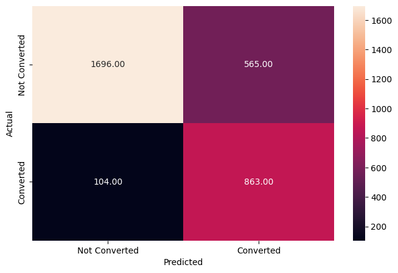

```
None
```

```python
# Check performance on the training data
y_pred_train2 = d_tree_tuned.predict(X_train)

accuracy = metrics_score(y_train, y_pred_train2)

print(accuracy)
```

```
              precision    recall  f1-score   support

           0       0.95      0.76      0.85       974
           1       0.62      0.90      0.73       410

    accuracy                           0.80      1384
   macro avg       0.78      0.83      0.79      1384
weighted avg       0.85      0.80      0.81      1384
```

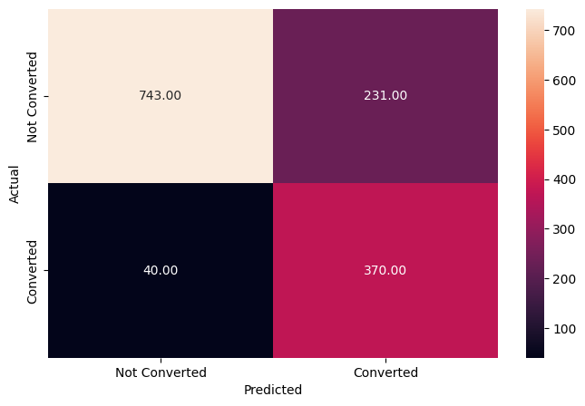

```
None
```

```python
# Checking performance on the test data
y_pred_test2 = d_tree_tuned.predict(X_test)

accuracy = metrics_score(y_test, y_pred_test2)

print(accuracy)
```

### Visualizing the Decision Tree

Let's visualize the tuned decision tree and observe the decision rules.

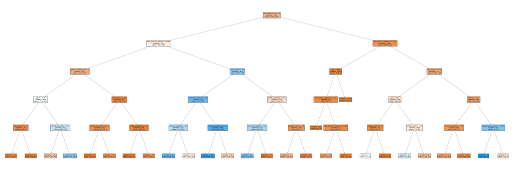

```python
# Draw the decision tree for the non-tuned model

features = list(X.columns)

plt.figure(figsize = (60, 20))

out = tree.plot_tree(d_tree, feature_names = features, impurity = False, filled = True, fontsize = 9, class_names = None)

for o in out:

    arrow = o.arrow_patch

    if arrow is not None:

        arrow.set_edgecolor('gray')

        arrow.set_linewidth(1)

plt.show()
```

### Observations

We observe that the highest converting set is the following, with 340 samples:

- First interaction <= 0.5 (Website)
- Time spent on website > 414
- Last activity <= 1.5 (Website, Email)
- Occupation > 0.5 (Professional, Student)
- Age > 25

The first split is on the First Interaction (Website, non-Website).

### Mapping for Categorical parameters

First Interaction:

- Website = 0
- Mobile App = 1

Last Activity:

- Website = 0
- Email = 1
- Phone = 2

Occupation:

- Unemployed = 0
- Professional = 1
- Student = 2

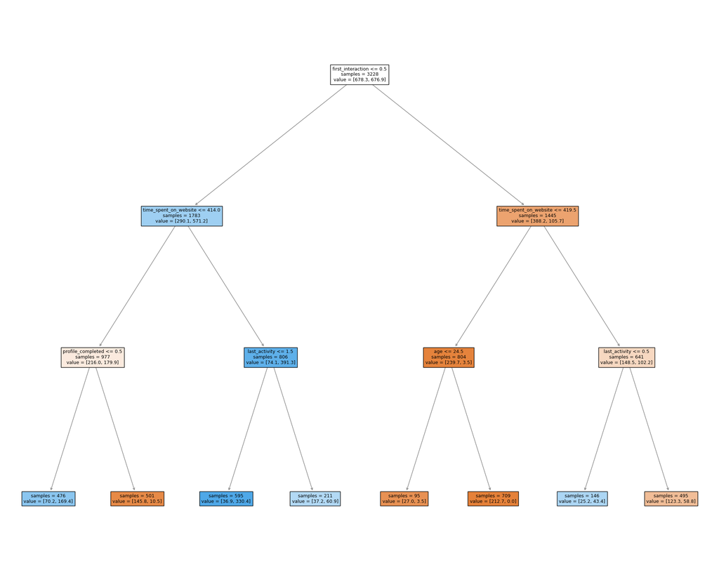

```python
# Draw the decision tree for the tuned model

features = list(X.columns)

plt.figure(figsize = (25, 20))

out = tree.plot_tree(d_tree_tuned, feature_names = features, impurity = False, filled = True, fontsize = 9, class_names = None)

for o in out:

    arrow = o.arrow_patch

    if arrow is not None:

        arrow.set_edgecolor('gray')

        arrow.set_linewidth(1)


plt.show()
```

### Observation

- First interaction <= 0.5 (Website)
- Time spent on website > 414
- Last activity <= 1.5 (Website, Email)

The first split is on the First Interaction (Website, non-Website).

### Misclassification errors

Visualize and compare error on the training and test data for different values of max_depth in the decision tree classifier.

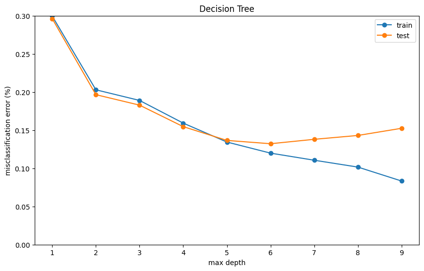

```python
# Visualize and compare error on the training and test data for different values of max_depth in the decision tree classifier.
train_scores = []
test_scores = []

for depth in range(1, 10):

    d_tree3 = tree.DecisionTreeClassifier(criterion = 'entropy', max_depth = depth)

    d_tree3 = d_tree3.fit(X_train, y_train)

    train_scores.append(1 - d_tree3.score(X_train, y_train))

    test_scores.append(1 - d_tree3.score(X_test, y_test))

plt.plot(range(1, 10), train_scores, '-o', label = "train")

plt.plot(range(1, 10), test_scores, '-o', label = "test")

plt.legend(loc = 'best')

plt.xlabel('max depth')

plt.ylabel('misclassification error (%)')

# Setting the range of the Y-axis
plt.ylim(0, 0.3)

plt.title(f"Decision Tree")

fig = plt.gcf()

fig.set_size_inches(10, 6)

plt.show()
```

### Observations

1. The training error continues to decrease as the maximum depth increases but the test error starts increasing after an initial decrease.
2. A model with low train error and high test error implies low bias and high variance of the model, i.e., the model has started to overfit the training data.
3. The train and the test error are close for max_depth = 1-5.
4. The max_depth = 5 seems like the "sweet spot" where training and test errors are balanced.

Now, let's see what would be the train and the test error for the same values of max_depth in a Random Forest Classifier.

Let's look at the feature importance of the tuned decision tree model

```python
# Importance of features in the tree building
print (pd.DataFrame(d_tree_tuned.feature_importances_, columns = ["Imp"], index = X_train.columns).sort_values(by = 'Imp', ascending = False))
```

```
                            Imp
time_spent_on_website  0.354900
first_interaction      0.331107
profile_completed      0.223107
last_activity          0.072285
age                    0.018600
current_occupation     0.000000
website_visits         0.000000
page_views_per_visit   0.000000
print_media_type1      0.000000
print_media_type2      0.000000
digital_media          0.000000
educational_channels   0.000000
referral               0.000000
```

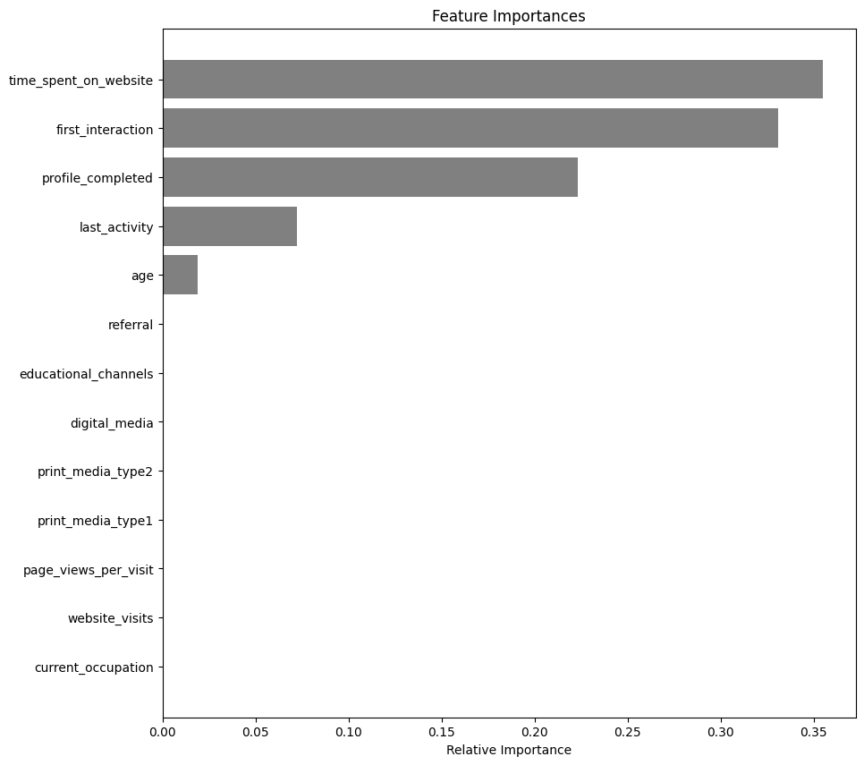

```python
# Plotting the feature importance
importances = d_tree_tuned.feature_importances_

indices = np.argsort(importances)

plt.figure(figsize = (10, 10))

plt.title('Feature Importances')

plt.barh(range(len(indices)), importances[indices], color = 'gray', align = 'center')

plt.yticks(range(len(indices)), [features[i] for i in indices])

plt.xlabel('Relative Importance')

plt.show()
```

### **Random Forest Classifier**

### Building Random Forest Model

```python
# Fitting the random forest tree classifier on the training data
rf_estimator =  ensemble.RandomForestClassifier()

rf_estimator = rf_estimator.fit(X_train, y_train)
```

```python
# Checking performance on the training data
y_pred_train3 = rf_estimator.predict(X_train)
```

```python
# Checking performance on the testing data
y_pred_test3 = rf_estimator.predict(X_test)
```

Let's see if we can get a better model by tuning the random forest classifier

### **Random Forest Classifier - Hyperparameter Tuning**

Let's try tuning some of the important hyperparameters of the Random Forest Classifier.

We will not tune the `criterion` hyperparameter as we know from hyperparameter tuning for decision trees that `entropy` is a better splitting criterion for this data.

```python
# Choose the type of classifier
rf_estimator_tuned = RandomForestClassifier(criterion = "entropy", random_state = 7)

# Grid of parameters to choose from
parameters = {"n_estimators": [110, 120],
    "max_depth": [6, 7],
    "min_samples_leaf": [20, 25],
    "max_features": [0.8, 0.9],
    "max_samples": [0.9, 1],
    "class_weight": ["balanced",{0: 0.3, 1: 0.7}]
}

# Type of scoring used to compare parameter combinations - recall score for class 1
scorer = metrics.make_scorer(recall_score, pos_label = 1)

# Run the grid search on the training data using scorer=scorer and cv=5
grid_obj = GridSearchCV(rf_estimator_tuned, parameters, scoring = scorer, cv = 5)

grid_obj = grid_obj.fit(X_train, y_pred_train3)

# Save the best estimator to variable rf_estimator_tuned
rf_estimator_tuned = grid_obj.best_estimator_

# Fit the best estimator to the training data
rf_estimator_tuned = rf_estimator_tuned.fit(X_train, y_pred_train3)
```

```python
# Checking performance on the training data
y_pred_train4 = rf_estimator_tuned.predict(X_train)
```

```python
# Checking performance on the test data
y_pred_test4 = rf_estimator_tuned.predict(X_test)
```

One of the drawbacks of ensemble models is that we lose the ability to obtain an interpretation of the model. We cannot observe the decision rules for random forests the way we did for decision trees. So, let's just check the feature importance of the model.

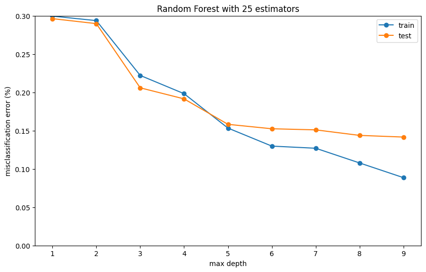

```python
# Visualize and compare error on the training and test data for different values of max_depth in the random forest classifier.
train_scores = []
test_scores = []

for depth in range(1, 10):

    rf1 = RandomForestClassifier(random_state = 0, criterion = 'entropy', max_depth = depth, n_estimators = 25)

    rf1 = rf1.fit(X_train, y_train)

    train_scores.append(1 - rf1.score(X_train, y_train))

    test_scores.append(1 - rf1.score(X_test, y_test))

plt.plot(range(1, 10), train_scores, '-o', label = "train")

plt.plot(range(1, 10), test_scores, '-o', label = "test")

plt.legend(loc = 'upper right')

plt.xlabel('max depth')

plt.ylim(0, 0.3)

plt.ylabel('misclassification error (%)')

plt.title(f"Random Forest with 25 estimators")

fig = plt.gcf()

fig.set_size_inches(10, 6)

plt.show()
```

### Observations

1. Random Forest helps to reduce overfitting problem in decision trees because it takes the average of several independent decision trees which helps to reduce the variance of the model.
2. In the above example, we are averaging the output of 25 decision trees.
3. At max depth > 5, the Random Forest model is reducing overfitting observed in individual decision trees.

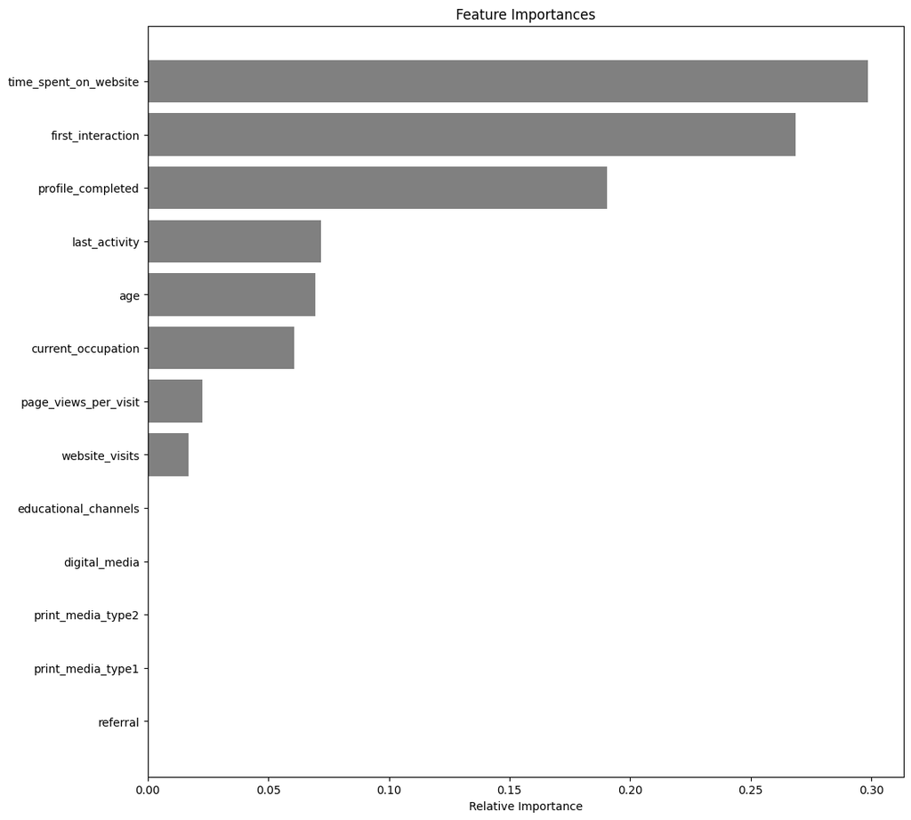

```python
importances = rf_estimator_tuned.feature_importances_

indices = np.argsort(importances)

feature_names = list(X.columns)

plt.figure(figsize = (12, 12))

plt.title('Feature Importances')

plt.barh(range(len(indices)), importances[indices], color = 'gray', align = 'center')

plt.yticks(range(len(indices)), [feature_names[i] for i in indices])

plt.xlabel('Relative Importance')

plt.show()
```

## **Conclusion and Recommendations**

### Business Recommendations

1. First interaction with the website/company is very important. Invest time and effort in making users' first interaction useful.
2. Professionals of age > 25 are driving the highest conversion on the website. Target this user segment for further growth.